# Task 3: Santa Barbara urchins

Anna Zauner

10/23/2021

## Overview

This task utilizes data from 5 sites along the Santa Barbara coast to explore and compare the size (diameter in cm) distribution of red and purple urchins using data visualization and descriptive statistics table. This data was recorded by Santa Barbara Coastal Ling Term Ecological Research program divers.

**Data citation**: Reed, D. 2020. SBC LTER: Reef: Long-term experiment: Kelp removal: Urchin size frequency distribution ver 20. Environmental Data Initiative. https://doi.org/10.6073/pasta/5a1e9ef03aa47bd2225c0bb98a02a63b.

## Set up

```r
knitr::opts_chunk$set(echo = TRUE, message = FALSE, warning = FALSE)

# Attach packages
library(tidyverse)
library(dplyr)
library(janitor)
library(here)
library(kableExtra)
library(lubridate)
library(scales)
```

## Read in data

Read in with `read_csv` and cleaned names with `clean_names()`

```r
urchins_data <- read_csv(here("data", "urchins.csv")) %>%
clean_names() %>%
rename(size_cm = size)
```

# Section 1

Size in diameter (cm) comparisons, purple and red urchins.

### Visualize the data

Created a faceted histogram with `facet_wrap()` to compare the distribution of sizes between purple and red urchins.

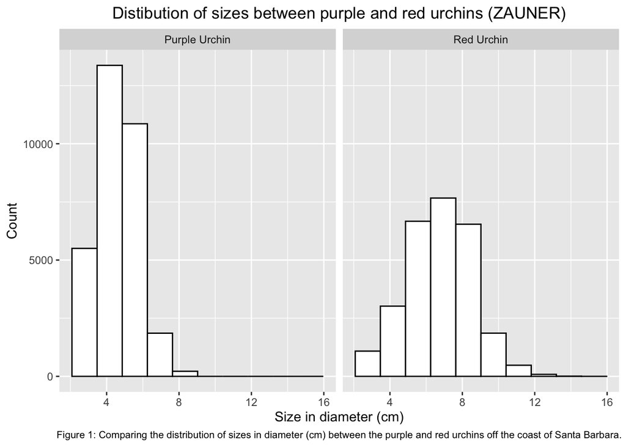

```r
ggplot(data = urchins_data, aes(x= size_cm))+
  geom_histogram(color= "black", fill= "white", bins = 10)+
  facet_wrap(~common_name)+
  labs(x = "Size in diameter (cm)",
       y = "Count",
       title = "Distibution of sizes between purple and red urchins (ZAUNER)",
       caption = "Figure 1: Comparing the distribution of sizes in diameter (cm) between the purple and red urchins off the coast of Santa Barbara.")+
  theme(plot.caption = element_text(hjust = 0.5, size = 8),
        plot.title = element_text(hjust = 0.5))
```

### Descriptive statistics

Created a table to summarize statistics for purple and red urchins by finding mean, median, standard deviation and sample size.

```r
urchins_summary <- urchins_data %>%
  group_by(common_name) %>%
  summarize(mean = mean(size_cm),
            median = median(size_cm),
            sd = sd(size_cm),
            sample_size = n()) %>%
  kable(caption = "Table 1: Summary statistics of urchin sizes",
        col.names = c("Urchin name",
                      "Mean (cm)",
                      "Median (cm)",
                      "Standard Deviation",
                      "Sample Size"),
        digits = 1) %>%
  kable_minimal()

urchins_summary
```

Table 1: Summary statistics of urchin sizes

| Urchin name | Mean (cm) | Median (cm) | Standard Deviation | Sample Size |
| --- | --- | --- | --- | --- |
| Purple Urchin | 4.5 | 4.5 | 1.2 | 31805 |
| Red Urchin | 6.8 | 7.0 | 1.9 | 27408 |

# Section 2

### Explore the purple urchin data

Compared purple urchin counts by site and year. Done by `filter()` only purple urchins, changing date class to “Date”,and creating new columns with year and full names of the sites where data was collected.

```r
purple_urchins <- urchins_data %>%
  filter(common_name == "Purple Urchin") %>%
  mutate(date_new = mdy(date)) %>%
  mutate(year_new = year(date_new)) %>%
  mutate(site_full = case_when(
    site == "NAPL" ~ "Naples Reef",
    site == "AQUE" ~ "Arroyo Quemado",
    site == "CARP" ~ "Carpinteria Reef",
    site == "MOHK" ~ "Mohawk Reef",
    site == "IVEE" ~ "Isla Vista Reef"
  ))
```

### Descriptive statistics

Created a table to store of total number of purple urchins observed by site and year.

```r
total_purple_site_year <- purple_urchins %>%
  group_by(site_full, year_new) %>%
  summarize(sample_size = n())
```

### Data visualization

Created graph of counts of purple urchins recorded at each site over time.

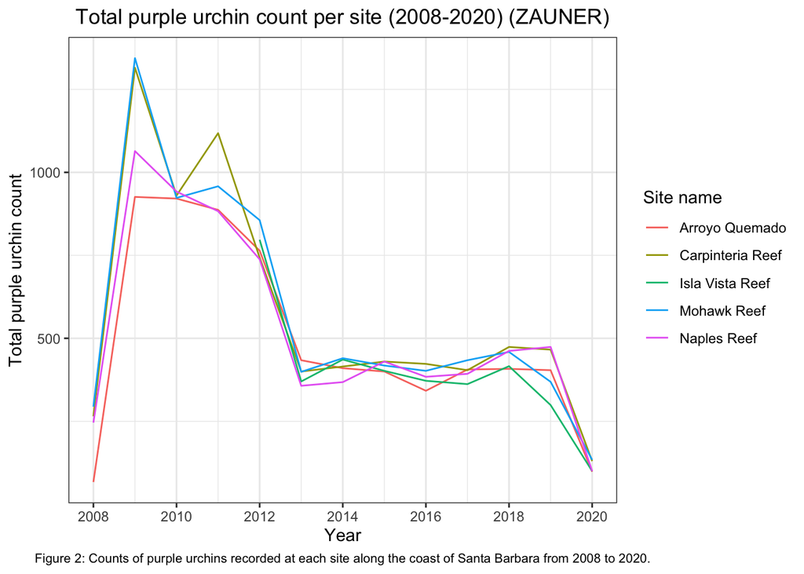

```r
ggplot(data = total_purple_site_year, aes(x = year_new, y = sample_size))+
  geom_line(stat = "identity")+
  aes(color = site_full)+
  labs(x = "Year",
       y = "Total purple urchin count",
       title = "Total purple urchin count per site (2008-2020) (ZAUNER)",
       color = "Site name",
       caption = "Figure 2: Counts of purple urchins recorded at each site along the coast of Santa Barbara from 2008 to 2020.")+
  theme_bw()+
  theme(plot.caption = element_text(hjust = 0.5, size = 8),
        plot.title = element_text(hjust = 0.5))+
  scale_x_continuous(breaks=c(2008, 2010, 2012, 2014, 2016, 2018, 2020))
```

**Figure 2:** This visualization may be a good representation of the changes in actual urchin population. This assumption can be made by taking into account the sample size of the population, n=31805 for purple urchins.Based on this large sample size it is fair to say that the data may be representative of the actual population. One must also consider the treatments in the study, which includes a control group (giant kelp left intact) and an annual group (giant kelp removed once each winter and allowed to re-colonize over the year). These different treatments were not taken into account in the data visualization for figure 2. Other factors that should be taken into account are how to data was collected, if there was a change in data collection by the divers over the course of the study. Other external environmental factors influencing the urchin population could include change in water temperature, nutrient levels or predation.